# Final Project Notebook

DS 5001 Text as Data

# Metadata

- Full Name: Aniyah McWilliams
- Userid: ybf3jw
- GitHub Repo URL: https://github.com/aniyahlater/ds5001_final_project
- UVA Box URL: https://virginia.app.box.com/collection/37041623526

# Overview

The goal of the final project is for you to create a **digital analytical edition** of a corpus using the tools, practices, and perspectives you’ve learning in this course. You will select a corpus that has already been digitized and transcribed, parse that into an F-compliant set of tables, and then generate and visualize the results of a series of fitted models. You will also draw some tentative conclusions regarding the linguistic, cultural, psychological, or historical features represented by your corpus. The point of the exercise is to have you work with a corpus through the entire pipeline from ingestion to interpretation.

Specifically, you will acquire a collection of long-form texts and perform the following operations:

- **Convert** the collection from their source formats (F0) into a set of tables that conform to the Standard Text Analytic Data Model (F2).
- **Annotate** these tables with statistical and linguistic features using NLP libraries such as NLTK (F3).
- **Produce** a vector representation of the corpus to generate TFIDF values to add to the TOKEN (aka CORPUS) and VOCAB tables (F4).
- **Model** the annotated and vectorized model with tables and features derived from the application of unsupervised methods, including PCA, LDA, and word2vec (F5).
- **Explore** your results using statistical and visual methods.
- **Present** conclusions about patterns observed in the corpus by means of these operations.

When you are finished, you will make the results of your work available in GitHub (for code) and UVA Box (for data). You will submit to Gradescope (via Canvas) a PDF version of a Jupyter notebook that contains the information listed below.

# Some Details

- Please fill out your answers in each task below by editing the markdown cell.
- Replace text that asks you to insert something with the thing, i.e. replace `(INSERT IMAGE HERE)` with an image element, e.g. `![](image.png)`.
- For URLs, just paste the raw URL directly into the text area. Don't worry about providing link labels using `[label](link)`.
- Please do not alter the structure of the document or cell, i.e. the bulleted lists.
- You may add explanatory paragraphs below the bulleted lists.
- Please name your tables as they are named in each task below.
- Tasks are indicated by headers with point values in parentheses.

# Raw Data

## Source Description (1)

Provide a brief description of your source material, including its provenance and content. Tell us where you found it and what kind of content it contains.

The primary source material that will be analyzed throughout this project is Jet Magazine. Jet magazine was a weekly published magazine from 1951 to 2014. Jet magazine was a groundbreaking publishing achievement as it was black owned magazine whose target audience was African Americans in a time of social inequality. The magazine covered a wide range of topics from fashion, entertainment, current affairs, beauty, art, and much more.

The analysis will be conducted on 10 issues of Jet magazine that range from 1951 to 1978. The magazine archives were collected from the website, Internet Archive. The process of collecting the magazines was downloading each individual magazine from the website in epub format. After each magazine was downloaded in the epub format a parser function was passed on each document to gather the text.

## Source Features (1)

Add values for the following items. (Do this for all following bulleted lists.)

- Source URL:
  - https://archive.org/details/@aniyah_mcwilliams/lists/1/ds-5001%3A-final-project-data
- UVA Box URL:
  - https://virginia.box.com/s/j7q4cpuqu1s5ph5icmcdrqqcjk6bjbww
- Number of raw documents:
  - 10
- Total size of raw documents (e.g. in MB):
  - 178 MB
- File format(s), e.g. XML, plaintext, etc.:
  - EPUB

## Source Document Structure (1)

Provide a brief description of the internal structure of each document. That, describe the typical elements found in document and their relation to each other. For example, a corpus of letters might be described as having a date, an addressee, a salutation, a set of content paragraphs, and closing. If they are various structures, state that.

The internal structure of each magazine consists of mini articles that focus on different events, situations, and trends, that fall under key magazine discussions. Jet magazine focused on fashion, beauty and key political events so the magazine has short form articles that span across those dommains.

Each mini article consists of a headline, a brief introduction, two or three body paragraphs, and a conclusing paragraph. These mini articles are usually accompanied by images. Each mini article is consistent in its brevity, there is variation in which some articles are more image-focused and others are more text-focused.

Unfortunately, due to how messy the data was it is difficult to break up the text by its articles and which headline it belongs under. Therefore the OHCO structure for this analysis will be reduced to the magazine id and page number.

# Parsed and Annotated Data

Parse the raw data into the three core tables of your addition: the `LIB`, `CORPUS`, and `VOCAB` tables.

These tables will be stored as CSV files with header rows.

You may consider using `|` as a delimitter.

Provide the following information for each.

## LIB (2)

The source documents the corpus comprises. These may be books, plays, newspaper articles, abstracts, blog posts, etc.

Note that these are *not* documents in the sense used to describe a bag-of-words representation of a text, e.g. chapter.

- UVA Box URL:
  - https://virginia.box.com/s/cq4a3yvzn04z2cbjethhqxgehdw3tr4v
- GitHub URL for notebook used to create:
  - https://github.com/aniyahlater/ds5001_final_project/blob/main/Cleaning%20and%20Derived%20Tables.ipynb
- Delimitter:
  - ','
- Number of observations:
  - 10
- List of features, including at least three that may be used for model summarization (e.g. date, author, etc.):
  - Date published
  - Quarter published
  - Length of magazine in characters
  - Month published
  - Length of magazine in characters
  - Page numbers
  - epub_id
- Average length of each document in characters:
  - 82871.1

IMPORTANT: I don't know why the LIB table is showing up like that in canvas but I promise it is in the right format. I tried downloaiding the table with different delimtters and how it appeared in UVA Box still looked weird. I apologize about this.

## CORPUS (2)

The sequence of word tokens in the corpus, indexed by their location in the corpus and document structures.

- UVA Box URL:
  - https://virginia.box.com/s/ptvsd5ynb6m25vsxshloa7xvaxlofs41
- GitHub URL for notebook used to create:
  - https://github.com/aniyahlater/ds5001_final_project/blob/main/Cleaning%20and%20Derived%20Tables.ipynb
- Delimitter:
  - ','
- Number of observations Between (should be >= 500,000 and <= 2,000,000 observations.):
  - 131948
- OHCO Structure (as delimitted column names):
  - mag_id: represents the magazine id
  - page_num: represents the page number
  - token_num: represents the token number associated with the token
- Columns (as delimitted column names, including `token_str`, `term_str`, `pos`, and `pos_group`):
  - mag_id
  - page_num
  - token_num
  - pos
  - pos_group
  - token_str
  - term_str

## VOCAB (2)

The unique word types (terms) in the corpus.

Top 20 in descending order:

1. shells
2. springfield
3. squad
4. demonstrate
5. demands
6. delores
7. delivery
8. stabbed
9. delicate
10. stadium
11. delaware
12. deknight
13. definitely
14. standard
15. defendant
16. defeated
17. defeat
18. dedicated
19. declined
20. starred

Reference Image:

[figure not shown]

# Derived Tables

## BOW (3)

A bag-of-words representation of the CORPUS.

## DTM (3)

A represenation of the BOW as a sparse count matrix.

- UVA Box URL:
  - https://virginia.box.com/s/8i4469wsljp3ao92n7ckmh3ybb7f8j0d
- UVA Box URL of BOW used to generate (if applicable):
  - https://virginia.box.com/s/ex1utygvakf0783huh8bzza8qqp94061
- GitHub URL for notebook used to create:
  - https://github.com/aniyahlater/ds5001_final_project/blob/main/Cleaning%20and%20Derived%20Tables.ipynb
- Delimitter:
  - ','
- Bag (expressed in terms of OHCO levels):
  - mag_id

## TFIDF (3)

A Document-Term matrix with TFIDF values.

- UVA Box URL:
  - https://virginia.box.com/s/ablbf1foqse6cex3cxop6s60uyz1dg6v
- UVA Box URL of DTM or BOW used to create:
  - https://virginia.box.com/s/8i4469wsljp3ao92n7ckmh3ybb7f8j0d
- GitHub URL for notebook used to create:
  - https://github.com/aniyahlater/ds5001_final_project/blob/main/Cleaning%20and%20Derived%20Tables.ipynb
- Delimitter:
  - ','
- Description of TFIDIF formula ($\LaTeX$ OK):
  - $(\log_2(1 + DTM)) * (\log_2(N/DF)) $
    - DTM: Document Term Matrix (referred to as DTCM in my code)
    - N: Length of DTM
    - DF: Document Frequency

## Reduced and Normalized TFIDF_L2 (3)

A Document-Term matrix with L2 normalized TFIDF values.

- UVA Box URL:
  - https://virginia.box.com/s/1400hzbojnu84lqw27usmsko9vn99v1y
- UVA Box URL of source TFIDF table:
  - https://virginia.box.com/s/c6zkhne2oug4rh4uzt1uot5zu2nd32t3
- GitHub URL for notebook used to create:
  - https://github.com/aniyahlater/ds5001_final_project/blob/main/Cleaning%20and%20Derived%20Tables.ipynb
- Delimitter:
  - ','
- Number of features (i.e. significant words):
  - 6023
- Principle of significant word selection:
  - The threshold used was 0.34. The original quality of this data was very poor so I decided to increase the threshold in an attempt to filter out some of the noisy, uncleaned words that I couldn't fully remove during the preprocessing stage. Since 'dh' represents the entropy of each word, my intuition was that by increasing the threshold i could remove outliers (common words as well as messy words I couldnt remove).

# Models

## PCA Components (4)

- UVA Box URL:
  - https://virginia.box.com/s/3c6rhq7jol2mjx7hrqgk7o10p991i69d
  - the above link is to the folder that has a csv for every table generated for PCA
  - https://virginia.box.com/s/rk10lrrrf5l5w751s963bskjmgcp1i1z
  - the above link is to the specific table generated to look at the top positive and negative terms for PCA
- UVA Box URL of the source TFIDF_L2 table:
  - https://virginia.box.com/s/1400hzbojnu84lqw27usmsko9vn99v1y
- GitHub URL for notebook used to create:
  - https://github.com/aniyahlater/ds5001_final_project/blob/main/PCA%26LDA.ipynb
- Delimitter:
  - ','
- Number of components:
  - 3
- Library used to generate:
  - sklearn.decomposition
- Top 5 positive terms for first component:
  - blacks
  - reggie
  - ali
  - mg
  - ms
- Top 5 negative terms for second component:
  - reggie
  - ruby
  - doby
  - watson
  - mg

While some noise was able to slip into the PCA, such as 'mg' (which i believe is a acronym for magazine) and 'ms', we can see that the the most positive word for the first component included 'blacks', 'reggie', and 'ali'. This supports the idea that Jet magazine centered its language on uplifting the black community. This was porbably achieved by talking positively about predominant black figures through out this time period such as Reggie Jackson and Muhammad Ali. Howevere, the most negative terms for the second component are mostly centered around black figures such as Reggie Jackson and Ruby Hurley. While they are the most negative terms, I believe this arrives due to their positons in a turbulent and segregrated United States of America. For example Jackson played in the Major League Baseball during segregration and the article could also be referencing racial attacks he experience throughout his time. Thus, most of the negative terms for the second component could be a due to Jet magazine highlighting their negative experiences and encounters.

## PCA DCM (4)

The document-component matrix generated.

- UVA Box URL:
  - https://virginia.box.com/s/ahw24p0ynnhgcfm63fd1wegb027rcclx
- GitHub URL for notebook used to create:
  - https://github.com/aniyahlater/ds5001_final_project/blob/main/PCA%26LDA.ipynb
- Delimitter:
  - ','

## PCA Loadings (4)

The component-term matrix generated.

- UVA Box URL:
  - https://virginia.box.com/s/yfzomxv3bm3ggzap11kp36ls0rzyh7ow
- GitHub URL for notebook used to create:
  - https://github.com/aniyahlater/ds5001_final_project/blob/main/PCA%26LDA.ipynb
- Delimitter:
  - ','

## PCA Visualization 1 (4)

Include a scatterplot of documents in the space created by the first two components.

Color the points based on a metadata feature associated with the documents.

Also include a scatterplot of the loadings for the same two components. (This does not need a feature mapped onto color.)

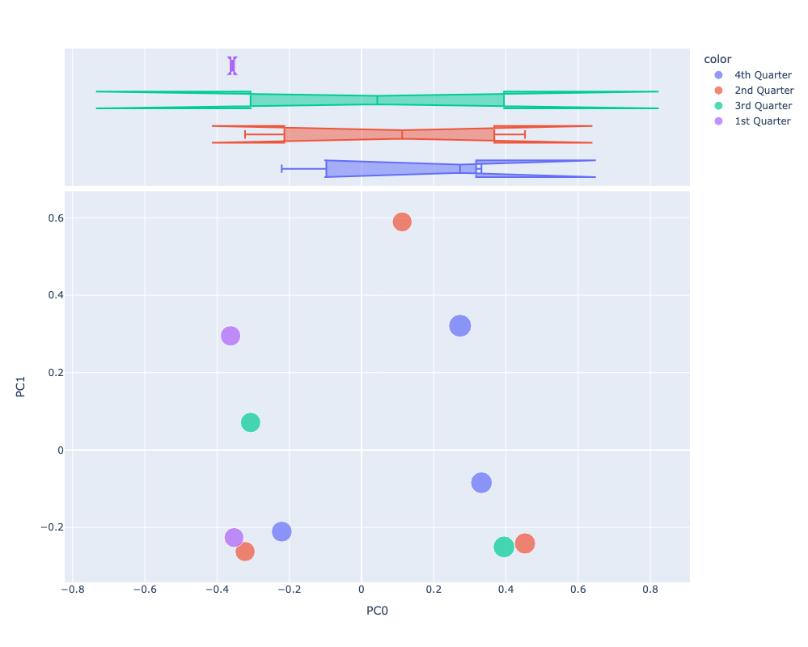

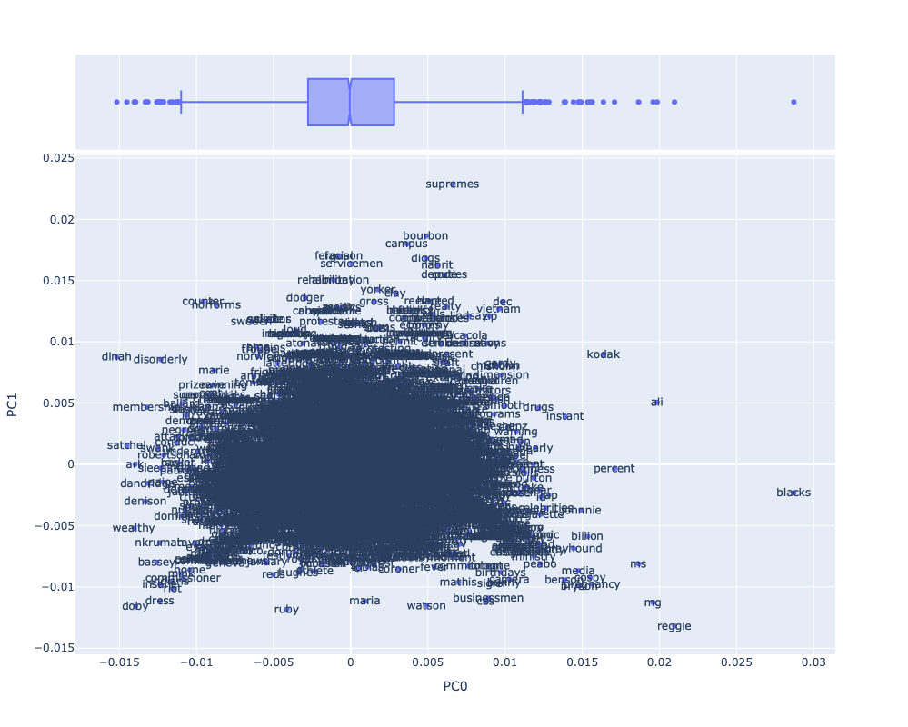

Briefly describe the nature of the polarity you see in the first component:

In the scatterplot of documents created by the first two components there is some interesting clustering going on. First, any JET magazine whose title exclusively focuses on a celebrity is tightly clustered around 0.4 on the x-axis (PCO). The key titles that are clustered around 0.4 are 'New Reggie Defends His Hero Image', 'Benson Shares His Fame With Family', and 'Tito Jackson: His Music and His Family'. More broadly, any magazine whose magazine title mentions a celebrity is above 0 on the x-axis. This also includes the titles such as 'What's Behind Suicide of Charles Diggs Sr.?' and 'What Dope Arrest is Doing to Career of Barbara McNair'. The way that these titles are organized on X-axis (PC0) leads me to believe that 0 and above are referring to celebrity life. However as you move further from 0 it focuses on the more glamorized aspects of celebrity life such as sharing fame and being a great parent. On the other hand, being closer to 0 represents less polished celebrity stories such as dealing with substance use, drug addiction, and suicidal ideation. Further, the magazines that are below 0 show a greater focus towards politics. These magazine titles include things like 'How Negroes Feel about a Catholic for US President', 'Why Cuban Rebels Jailed Son of Wealthy Negro', and 'First Poll Reveals Candidates Negroes want for president'. However, many of these titles below zero have two titles that appear on the magazine. This also leads me ot believe that all the celebrity magazines above 0 are special editions, in which more of the text is dedicated towards the primary article and there is less mini-articles across many domains.

After analyzing the PC0 and the PC1 scatterplot, I am lead to conclude that this visualization represents the spectrum from more grounded, raw, political focused Jet magazines to more idealized, clean, and celebrity-focused Jet magazines. The scatterplot visualization of loadings supports this analysis. For example, words that are seen in the lower, left section of the scatter plot include 'klan', 'whipped', 'rape', 'poison', 'admissions', 'congregration' and much more.

The points are colored based on what quarter of the year the magazine was published. Unfortunately, there is no clear relationship between what quarter the magazine was published and these two components.

## PCA Visualization 2 (4)

Include a scatterplot of documents in the space created by the second two components.

Color the points based on a metadata feature associated with the documents.

Also include a scatterplot of the loadings for the same two components. (This does not need a feature mapped onto color.)

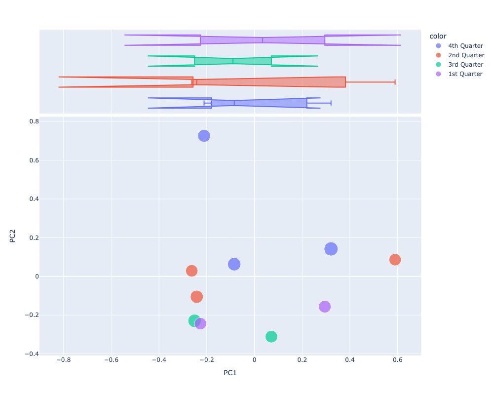

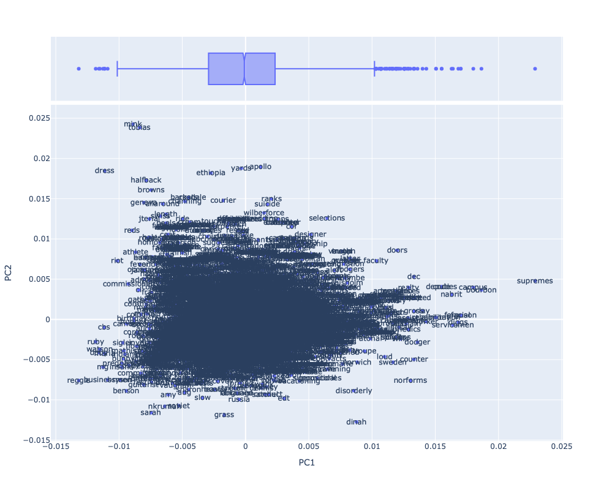

Briefly describe the nature of the polarity you see in the second component:

I had more difficulty with first assessing this visualization. In an attempt to deal with that I looked at the only outlier which was titled 'Ten Ways to Get a Mink Coat/Why Negro Suicides are Increasing'.

## LDA TOPIC (4)

- UVA Box URL:
  - https://virginia.box.com/s/0lyjvu5g9cwifc989o7szrnlo52uzh15
- UVA Box URL of count matrix used to create:
  - https://virginia.box.com/s/rr7krxjm5g32spz1nvy71de7n1ixu4yk
- GitHub URL for notebook used to create:
  - https://github.com/aniyahlater/ds5001_final_project/blob/main/PCA.ipynb
- Delimitter:
  - ','
- Libary used to compute:
  - sklearn.decomposition
- A description of any filtering, e.g. POS (Nouns and Verbs only):
  - Only used nouns
- Number of components:
  - 5 (I'm assuming this means topics)
- Any other parameters used:
  - stop_words='english' --> creating my own stop words did worse
  - max_df=0.5 --> shows up in no more than 50% of the documents
  - min_df=4 --> shows up in no less than 4 of the documents
- Top 5 words and best-guess labels for topic five topics by mean document weight:
  - T00: [cent window total negroes candidates] songs aterial ceremony pennant theater--> Public events, civic life, and entertainment
  - T01: [price blacks guest mayor seats] pair agency loan drinking level --> Urban and local community focused articles
  - T02: [blacks test percent copy course] celebrities youth dog sports freedom --> Youth, education, and media
  - T03: [heat places changes failure establishment] rumors emergency vows lawmaker absence --> Political developments and crises
  - T04: [blacks campus percent cent survey] university union legislation population workers --> Higher education activism and surveys

Important: I did the top 10 terms because the LDA was not providing me a clear enough topic with only the top five. The data is just so messy unfortunately.

## LDA THETA (4)

- UVA Box URL:
  - https://virginia.box.com/s/2ysjxf985wq0yeixv4lrtn24rj3waula
- GitHub URL for notebook used to create:
  - https://github.com/aniyahlater/ds5001_final_project/blob/main/PCA%26LDA.ipynb
- Delimitter:
  - ','

## LDA PHI (4)

- UVA Box URL:
  - https://virginia.box.com/s/waxuojkbfgfd3tai2en92etm6ig10lhq
- GitHub URL for notebook used to create:
  - https://github.com/aniyahlater/ds5001_final_project/blob/main/PCA%26LDA.ipynb
- Delimitter:
  - ','

## LDA + PCA Visualization (4)

Apply PCA to the THETA table and plot the topics in the space opened by the first two components.

Size the points based on the mean document weight of each topic (using the THETA table).

Color the points basd on a metadata feature from the LIB table.

Provide a brief interpretation of what you see.

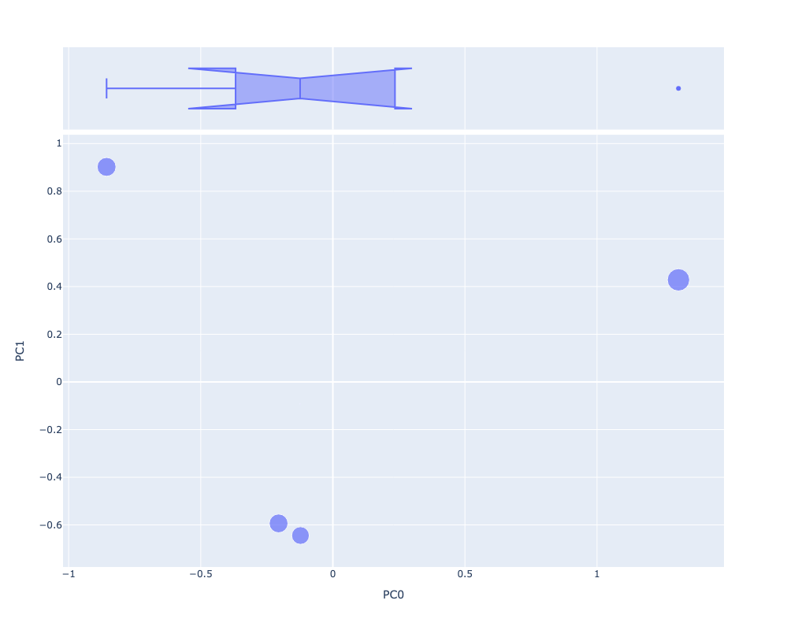

IMPORTANT: - Couldn't color due to there only being 5 topics. I believe you are asking me to to 'plot the topics' however number of topics != metadata length in lib table. - There are 5 topics plotted but the T3 is veryyyy tiny

Interpretaion:

The two topics that are the most closely related are T0 and T2. This is probably due to their overlap in content. T0 focuses on public events and entertainment. On the other hand, T2 focuses on youth and media.

Topic T3 is very small due to its mean document weight (0.0005).

There doesn't seem to be a clear pattern between these two principal components and the mean document weight of each topic.

## Sentiment VOCAB_SENT (4)

Sentiment values associated with a subset of the VOCAB from a curated sentiment lexicon.

- UVA Box URL:
  - https://virginia.box.com/s/v7dziyonrvnwbi7iokjao5i0ypezkhkk
- UVA Box URL for source lexicon:
  - https://virginia.box.com/s/l2479n703uq5l1o32l4us6nxo3g7hzsm
- GitHub URL for notebook used to create:
  - https://github.com/aniyahlater/ds5001_final_project/blob/main/sentiment_analysis.ipynb
- Delimitter:
  - ','

## Sentiment BOW_SENT (4)

Sentiment values from VOCAB_SENT mapped onto BOW.

- UVA Box URL:
  - https://virginia.box.com/s/7cpqbqcvosop0cgidwzr3pgbiq0kthaj
- GitHub URL for notebook used to create:
  - https://github.com/aniyahlater/ds5001_final_project/blob/main/sentiment_analysis.ipynb
- Delimitter:
  - ','

## Sentiment DOC_SENT (4)

Computed sentiment per bag computed from BOW_SENT.

- UVA Box URL:
  - https://virginia.box.com/s/un5khssz0l6thmwb85dnq9yvelv0q6cg
- GitHub URL for notebook used to create:
  - https://github.com/aniyahlater/ds5001_final_project/blob/main/sentiment_analysis.ipynb
- Delimitter:
  - ','
- Document bag expressed in terms of OHCO levels:
  - 'mag_id'

## Sentiment Plot (4)

Plot sentiment over some metric space, such as time.

If you don't have a metric metadata features, plot sentiment over a feature of your choice.

You may use a bar chart or a line graph.

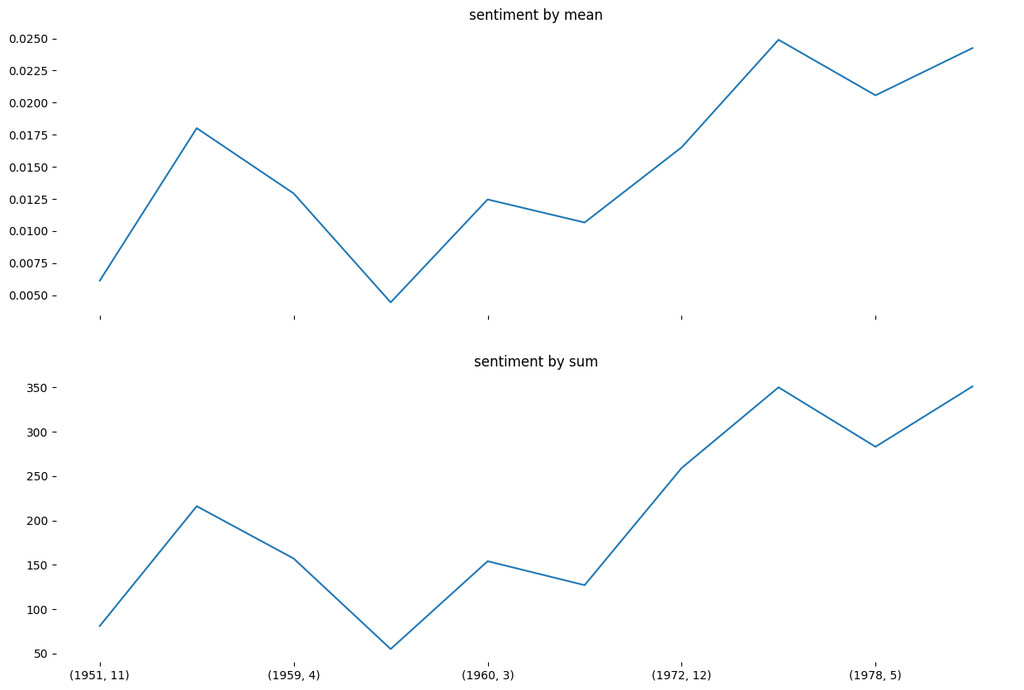

The previous image the mean and overall sentiment of the magazines ploted over the years that they were released. It seems that both the overall and mean sentiment have increased over time. However, the mean sentiment has only increased on a very small scale.

## VOCAB_W2V (4)

A table of word2vec features associated with terms in the VOCAB table.

- UVA Box URL:
  - https://virginia.box.com/s/xbfo9ipzi6zxkopm2shw7z9wxyrasd2e
- GitHub URL for notebook used to create:
  - https://github.com/aniyahlater/ds5001_final_project/blob/main/word2vec.ipynb
- Delimitter:
  - ','
- Document bag expressed in terms of OHCO levels:
  - 'mag_id'
- Number of features generated:
  - 100
- The library used to generate the embeddings:
  - genism

## Word2vec tSNE Plot (4)

Plot word embedding featues in two-dimensions using t-SNE.

Describe a cluster in the plot that captures your attention.

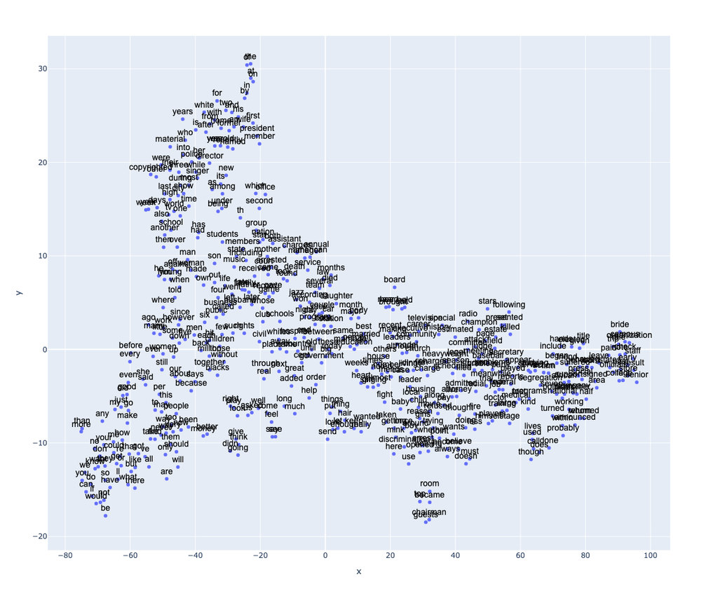

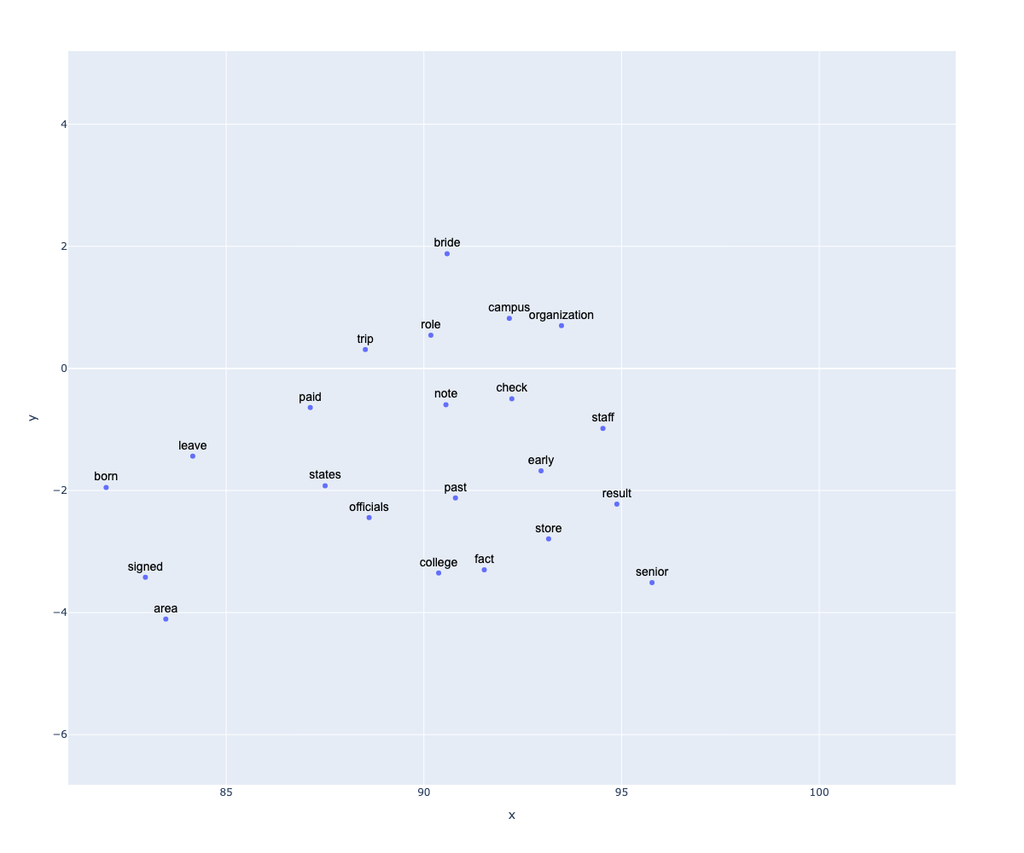

I chose the cluster that is the furtherest to the right. The words that are in this cluster include 'campus', 'states', 'college', 'area','senior','organization', and 'staff'. This cluster is interesting because it relates to organizational events and structures.

# Riffs

Provde at least three visualizations that combine the preceding model data in interesting ways.

These should provide insight into how features in the LIB table are related.

The nature of this relationship is left open to you -- it may be correlation, or mutual information, or something less well defined.

In doing so, consider the following visualization types:

- Hierarchical cluster diagrams
- Heatmaps
- Scatter plots
- KDE plots
- Dispersion plots
- t-SNE plots
- etc.

## Riff 1 (5)

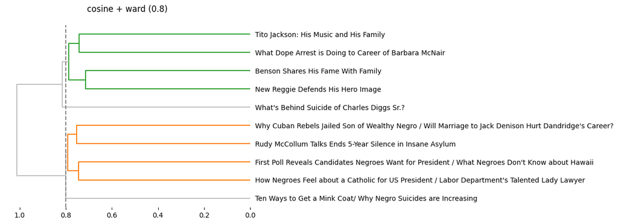

When looking at the denrodrogram we see that the magazines are broken into two primary groups. The first primary group consists of 3 clades that results in four leaves. The four leaves are the following: 'Tito Jackson: His Music and His Family', 'What Dope Arrest is Doing to Career of Barbara McNair', 'Benson Shares His Fame With Family', and 'New Reggie Defends His Hero Image'. These four magazines are the closest to one another due to their central focus on a celebrity figure. Interestingly, the other magazine that is closest to these clades is titled, 'What's Behind Suicide of Charles Diggs Sr.?' which also focuses on a celebrity but not in the same positive light as the other magazines.

The second primary group focuses primarily on more political and survey focused information.

## Riff 2 (5)

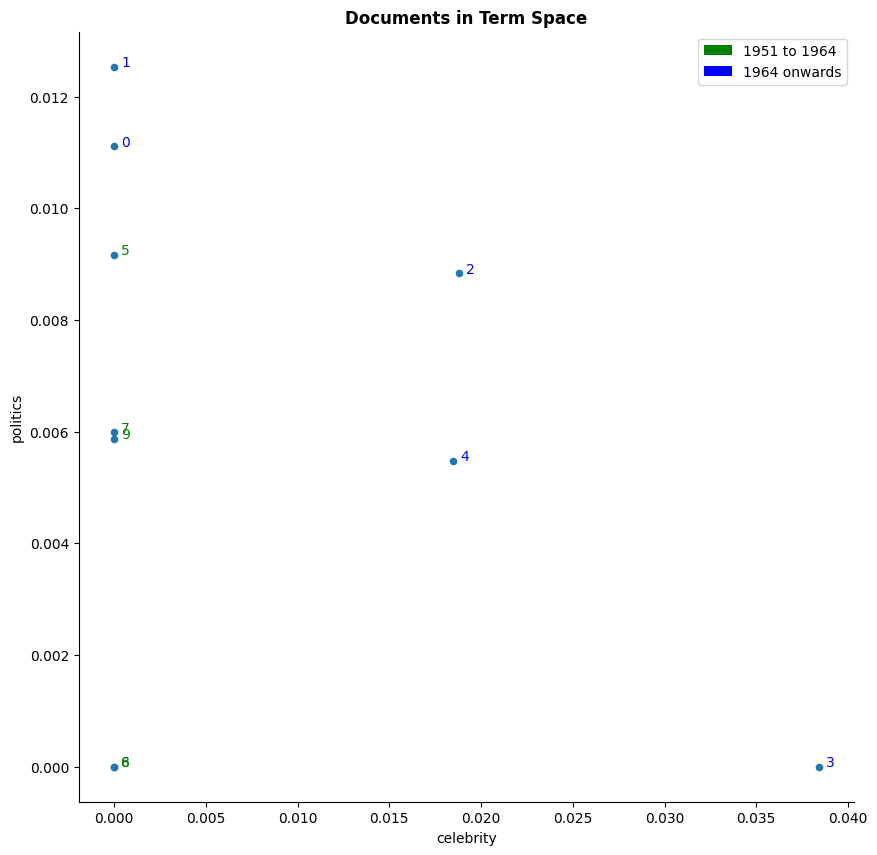

IMPORTANT: Chose to do mag_id instead of title because the title names would overlap alot

## Riff 3 (5)

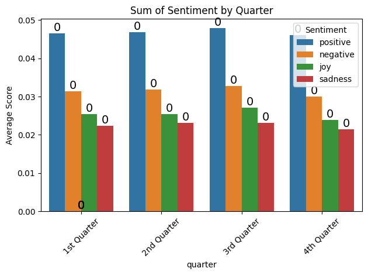

The above visualiation depicts the average sentiment by quarter for all 10 Jet magazines. Since the average sentiment is so low for each quarter the numbers above each bar reads as 0. There doesn't appear to be any significant changes or trends with how the sentiment appears over the publishing quarter. Interestingly, the sentiments that have the highest average are positive and negative, while joy and sadness are the lowest.

# Interpretation (4)

Describe something interesting about your corpus that you discovered during the process of completing this assignment.

At a minumum, use 250 words, but you may use more. You may also add images if you'd like.

I originally set out with the intention of observing how beauty was discussed in black media. However, due to the messiness of the data and lack of accessibility to more data, my analysis had to be shifted. I will preface that the analysis that was conducted on the available magazines was limited due to those two factors, in the future I would look for other sources to obtain cleaner data for a more informative analysis. However, throughout this analysis I was able to gain some interesting insights.

To further investigate how the earlier issues focused on certain topics I built a heatmap that looks at topics by magazine_id.

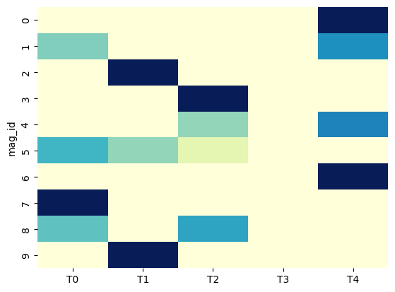

In the visualization you can see that magazines whose id was 7, 8, and 5 were the most heavily associated with topic T0. T0 represents public events, civic life, and entertainment. All of these magazines were published in the 50’s. On the other hand, magazines whose id was 0, 1, 4, and 6 were the most heavily associated with topic T4. T4 represents higher education activism and surveys. All of these magazines were published after 1960.